# No-Show Appointments

- Introduction
- Data Wrangling
- Exploratory Data Analysis
- Conclusions

## Introduction

> In this analysis we'll be looking at the no show appointment dataset to try and predict what factors can help us predict if patients will show up for their scheduled appointments or not. This dataset contains information from medical appointments from Brazil and characteristics about the patients. I go on to analyze and see what characteristics we can use to predict patients showing up for an appointment or not. The variables in this dataset are; PatientId - unique identifier for patients AppointmentID - unique identifier for appointments Gender - sex of the patient(F is Female, M is Male) ScheduledDay - date scheduled for the appointment AppointmentDay - date that the appointment happened Age - is the age of the patient Neighbourhood - where the patient stays Scholarship - whether the patient is a beneficial of the govt fund for under priviledged groups Hipertension - 1 means patient has this illness 0 is they don't Diabetes - 1 means patient has this illness 0 is they don't Alcoholism 1 means patient has this illness 0 is they don't Handcap - 1 means patient has this illness 0 is they don't SMS_received - 1 of the patient received an sms 0 if they didn't No-show - No means the patient showed up for the appointment and yes means they didn't show up

> **The questions posed for this dataset are;** What factors are important for us to know in order to predict if a patient will show up for their scheduled appointment?

> The variables I used for this analysis are ; Dependent variable:No-show | Independent variables were: Gender,Scholarship,Sms received,Hipertension,Diabetes

```python
# import packages to use for the project
import pandas as pd
import numpy as np
import matplotlib.pyplot as plt
import seaborn as sns
import datetime
%matplotlib inline
```

## Data Wrangling

> In this section I load the data, check for cleanliness and choose what to trim from my dataset before I dive into the analysis.

### General Properties

```python
# Load your data and print out a few lines. Perform operations to inspect data
#   types and look for instances of missing or possibly errant data.
# load the dataset
df = pd.read_csv('noshowappointments-kagglev2-may-2016.csv')
df.head()
```

|  | PatientId | AppointmentID | Gender | ScheduledDay | AppointmentDay | Age | Neighbourhood | Scholarship | Hipertension | Diabetes | Alcoholism | Handcap | SMS_received | No-show |
| --- | --- | --- | --- | --- | --- | --- | --- | --- | --- | --- | --- | --- | --- | --- |
| 0 | 2.987250e+13 | 5642903 | F | 2016-04-29T18:38:08Z | 2016-04-29T00:00:00Z | 62 | JARDIM DA PENHA | 0 | 1 | 0 | 0 | 0 | 0 | No |
| 1 | 5.589978e+14 | 5642503 | M | 2016-04-29T16:08:27Z | 2016-04-29T00:00:00Z | 56 | JARDIM DA PENHA | 0 | 0 | 0 | 0 | 0 | 0 | No |
| 2 | 4.262962e+12 | 5642549 | F | 2016-04-29T16:19:04Z | 2016-04-29T00:00:00Z | 62 | MATA DA PRAIA | 0 | 0 | 0 | 0 | 0 | 0 | No |
| 3 | 8.679512e+11 | 5642828 | F | 2016-04-29T17:29:31Z | 2016-04-29T00:00:00Z | 8 | PONTAL DE CAMBURI | 0 | 0 | 0 | 0 | 0 | 0 | No |
| 4 | 8.841186e+12 | 5642494 | F | 2016-04-29T16:07:23Z | 2016-04-29T00:00:00Z | 56 | JARDIM DA PENHA | 0 | 1 | 1 | 0 | 0 | 0 | No |

```python
# explore dataset
df.info()
```

```
<class 'pandas.core.frame.DataFrame'>
RangeIndex: 110527 entries, 0 to 110526
Data columns (total 14 columns):
 #   Column          Non-Null Count   Dtype
---  ------          --------------   -----
 0   PatientId       110527 non-null  float64
 1   AppointmentID   110527 non-null  int64
 2   Gender          110527 non-null  object
 3   ScheduledDay    110527 non-null  object
 4   AppointmentDay  110527 non-null  object
 5   Age             110527 non-null  int64
 6   Neighbourhood   110527 non-null  object
 7   Scholarship     110527 non-null  int64
 8   Hipertension    110527 non-null  int64
 9   Diabetes        110527 non-null  int64
 10  Alcoholism      110527 non-null  int64
 11  Handcap         110527 non-null  int64
 12  SMS_received    110527 non-null  int64
 13  No-show         110527 non-null  object
dtypes: float64(1), int64(8), object(5)
memory usage: 11.8+ MB
```

After inspecting the dataset, as seen in the cells above, I decided that the Patient Id and AppointmentID won't be useful for the analysis I will be carrying out. I need to change the scheduledday and appointmentday data types from object to datetime to make manipulation of these columns possible.

### Data Cleaning

> In this sections I get my dataset ready for analysis. I need to make sure I have a dataset that has the right data types and variables I need for my analysis

```python
# remove columns that aren't relevant to the analysis
df.drop(['PatientId','AppointmentID'], axis=1, inplace=True)
df.head()
```

|  | Gender | ScheduledDay | AppointmentDay | Age | Neighbourhood | Scholarship | Hipertension | Diabetes | Alcoholism | Handcap | SMS_received | No-show |
| --- | --- | --- | --- | --- | --- | --- | --- | --- | --- | --- | --- | --- |
| 0 | F | 2016-04-29T18:38:08Z | 2016-04-29T00:00:00Z | 62 | JARDIM DA PENHA | 0 | 1 | 0 | 0 | 0 | 0 | No |
| 1 | M | 2016-04-29T16:08:27Z | 2016-04-29T00:00:00Z | 56 | JARDIM DA PENHA | 0 | 0 | 0 | 0 | 0 | 0 | No |
| 2 | F | 2016-04-29T16:19:04Z | 2016-04-29T00:00:00Z | 62 | MATA DA PRAIA | 0 | 0 | 0 | 0 | 0 | 0 | No |
| 3 | F | 2016-04-29T17:29:31Z | 2016-04-29T00:00:00Z | 8 | PONTAL DE CAMBURI | 0 | 0 | 0 | 0 | 0 | 0 | No |
| 4 | F | 2016-04-29T16:07:23Z | 2016-04-29T00:00:00Z | 56 | JARDIM DA PENHA | 0 | 1 | 1 | 0 | 0 | 0 | No |

In the cell above, I dropped the patient Id and appointment Id columns because they won't be used in my analysis

```python
# change the date columns(scheduledDay and AppointmentDay) from string data type to datetime data type
df['ScheduledDay'] = pd.to_datetime(df['ScheduledDay'])
df['AppointmentDay'] = pd.to_datetime(df['AppointmentDay'])
```

In the cell above, I changed the columns from object data type to datetime datatype

```python
# change the No-show column to No_show to enable data manipulation
df.rename(columns={'No-show':'No_show'}, inplace=True)
```

Changed the column name for the No-show column because manipulation would be hard with the previous naming

```python
# confirm that the columns have been converted
df.info()
```

```
<class 'pandas.core.frame.DataFrame'>
RangeIndex: 110527 entries, 0 to 110526
Data columns (total 12 columns):
 #   Column          Non-Null Count   Dtype
---  ------          --------------   -----
 0   Gender          110527 non-null  object
 1   ScheduledDay    110527 non-null  datetime64[ns, UTC]
 2   AppointmentDay  110527 non-null  datetime64[ns, UTC]
 3   Age             110527 non-null  int64
 4   Neighbourhood   110527 non-null  object
 5   Scholarship     110527 non-null  int64
 6   Hipertension    110527 non-null  int64
 7   Diabetes        110527 non-null  int64
 8   Alcoholism      110527 non-null  int64
 9   Handcap         110527 non-null  int64
 10  SMS_received    110527 non-null  int64
 11  No_show         110527 non-null  object
dtypes: datetime64[ns, UTC](2), int64(7), object(3)
memory usage: 10.1+ MB
```

## Exploratory Data Analysis

### What factors are important for us to know in order to predict if a patient will show up for their scheduled appointment?

```python
# get summary statistics for the dataset
df.describe()
```

|  | Age | Scholarship | Hipertension | Diabetes | Alcoholism | Handcap | SMS_received |
| --- | --- | --- | --- | --- | --- | --- | --- |
| count | 110527.000000 | 110527.000000 | 110527.000000 | 110527.000000 | 110527.000000 | 110527.000000 | 110527.000000 |
| mean | 37.088874 | 0.098266 | 0.197246 | 0.071865 | 0.030400 | 0.022248 | 0.321026 |
| std | 23.110205 | 0.297675 | 0.397921 | 0.258265 | 0.171686 | 0.161543 | 0.466873 |
| min | -1.000000 | 0.000000 | 0.000000 | 0.000000 | 0.000000 | 0.000000 | 0.000000 |
| 25% | 18.000000 | 0.000000 | 0.000000 | 0.000000 | 0.000000 | 0.000000 | 0.000000 |
| 50% | 37.000000 | 0.000000 | 0.000000 | 0.000000 | 0.000000 | 0.000000 | 0.000000 |
| 75% | 55.000000 | 0.000000 | 0.000000 | 0.000000 | 0.000000 | 0.000000 | 1.000000 |
| max | 115.000000 | 1.000000 | 1.000000 | 1.000000 | 1.000000 | 4.000000 | 1.000000 |

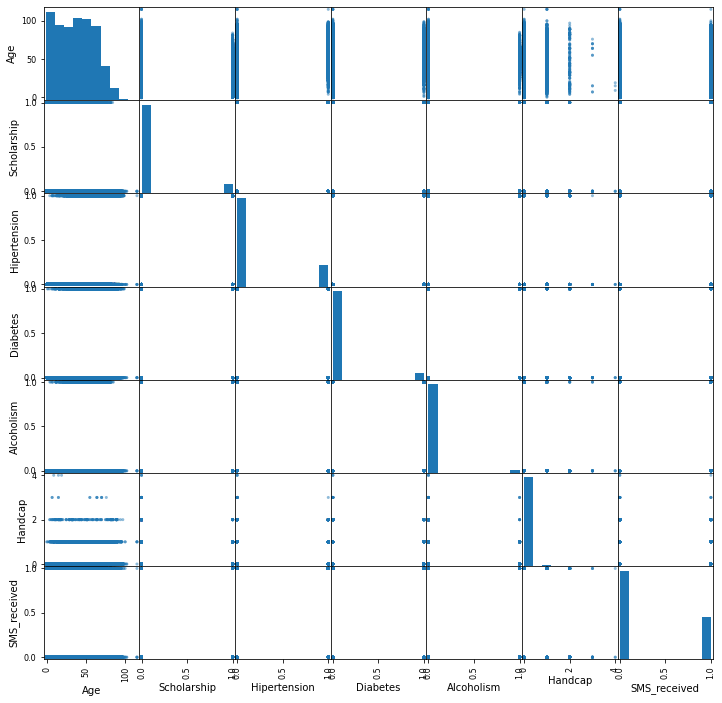

```python
# make a scatter matrix to understand the correlation between different variables.
pd.plotting.scatter_matrix(df,alpha=0.5, figsize=(12,12));
# df.plot(x='Age',y='Diabetes',kind='scatter');
```

The above scatter matrix shows there is no correlation among variables in this dataset. Therefore I will do a deeper dive into multiple variables to understand the relationship between patients going for appointments and not going.

**Predict appointment attendance by Gender**

Here I look at the effects of gender on patient appointments

```python
# get the mean age by gender to understand which gender has an older sample
df.groupby('Gender').Age.mean()
```

```
Gender
F    38.893987
M    33.736863
Name: Age, dtype: float64
```

```python
#get total counts for males and females
gender_split_totals = df.groupby('Gender').Age.count()
gender_split_totals
```

```
Gender
F    71840
M    38687
Name: Age, dtype: int64
```

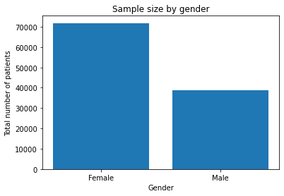

```python
# plot a chart to display distribution of patients by gender
locations = [1,2]
heights = gender_split_totals

labels = ['Female','Male']
plt.bar(locations,heights,tick_label=labels)
plt.title('Sample size by gender')
plt.xlabel('Gender')
plt.ylabel('Total number of patients')
plt.show()
```

The summary above shows there are more women than men in the sample. Therefore making conclusions basing on the absolute numbers won't be representative.

Plotting the above statistics on a graph

```python
# find out how age affects patients' possibility of showing up for an appointment or not

# get counts for each gender and whether they showed up for the appointment or not
gender_split_counts = df.groupby(['Gender','No_show']).count()['Age']
gender_split_counts
```

```
Gender  No_show
F       No         57246
        Yes        14594
M       No         30962
        Yes         7725
Name: Age, dtype: int64
```

```python
# create a function to calculate proportions of a selected variable.
# This function takes a variable counts and totals as parameters, and calculates the percentage contribution.

def proportions(count,total):
    return count/total
```

```python
# Get the female proportions by dividing the counts of females by the total
female_proportions = proportions(gender_split_counts['F'],gender_split_totals['F'])
female_proportions
```

```
No_show
No     0.796854
Yes    0.203146
Name: Age, dtype: float64
```

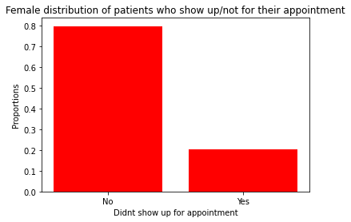

```python
# Plot the appointmemt data for females
locations = [1,2]
heights = female_proportions
labels = ['No','Yes']

plt.bar(locations,female_proportions,color='r',tick_label=labels)

# add labels
plt.title('Female distribution of patients who show up/not for their appointment')
plt.xlabel('Didnt show up for appointment')
plt.ylabel('Proportions');
```

```python
# Get the male proportions by dividing the counts of males by the total
male_proportions = proportions(gender_split_counts['M'],gender_split_totals['M'])
male_proportions
```

```
No_show
No     0.800321
Yes    0.199679
Name: Age, dtype: float64
```

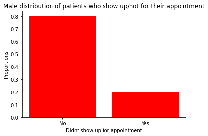

```python
# Plot the appointmemt data for males
locations = [1,2]
heights = male_proportions
labels = ['No','Yes']

plt.bar(locations,male_proportions,color='r',tick_label=labels)

# add labels
plt.title('Male distribution of patients who show up/not for their appointment')
plt.xlabel('Didnt show up for appointment')
plt.ylabel('Proportions');
```

**Summary**

From the results on gender, this variable can not be used to predict whether a patient will show up or not because both sexes behave the same.

**Predict appointment attendance by scholarship status**

Here I look at the likelyhood of a patient to go to an appointment using the scholarship variable. Does the government incentive encourage people to get to their appointments?

```python
# get the total of all people with scholarships and those without
scholarship_total = df.groupby('Scholarship').Age.count()
scholarship_total
```

```
Scholarship
0    99666
1    10861
Name: Age, dtype: int64
```

```python
# Because the samples between people who got a scholarship and those who didn't are irregular, we'll use proportions instead
# get scholarship distribution
scholarship_counts = df.groupby(['Scholarship','No_show']).Age.count()
scholarship_counts
```

```
Scholarship  No_show
0            No         79925
             Yes        19741
1            No          8283
             Yes         2578
Name: Age, dtype: int64
```

```python
# no scholarship and appointment attendance
no_scholarship = proportions(scholarship_counts[0],scholarship_total[0])
no_scholarship
```

```
No_show
No     0.801928
Yes    0.198072
Name: Age, dtype: float64
```

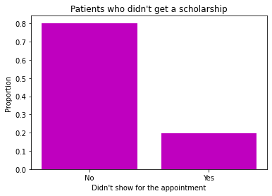

```python
# plot chart to show findings
locations = [1,2]
height = no_scholarship
labels=['No','Yes']

plt.bar(locations, height, color= 'm', tick_label=labels)

# add labels
plt.title('Patients who didn\'t get a scholarship')
plt.xlabel('Didn\'t show for the appointment')
plt.ylabel('Proportion');
```

```python
# got scholarship and appointment attendance
got_scholarship = proportions(scholarship_counts[1],scholarship_total[1])
got_scholarship
```

```
No_show
No     0.762637
Yes    0.237363
Name: Age, dtype: float64
```

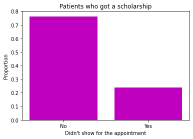

```python
# plot chart to show findings
locations = [1,2]
height = got_scholarship
labels=['No','Yes']

plt.bar(locations, height, color= 'm', tick_label=labels)

# add labels
plt.title('Patients who got a scholarship')
plt.xlabel('Didn\'t show for the appointment')
plt.ylabel('Proportion');
```

**Summary**

Patients who aren't on the scholarship tend to show up to their appointments with ~80% of patients showing up compared to 76% of patients who were on a scholarship. Seems this variable can't be used to determine probability of patients showing up.

**Predict appointment attendance by SMS RECEIVED**

Here I look at how sending reminder smses to patients affects whether they show up for appointments or not.

```python
# get the total of all people who received an sms and those who didn't
sms_received_total = df.groupby('SMS_received').Age.count()
sms_received_total
```

```
SMS_received
0    75045
1    35482
Name: Age, dtype: int64
```

```python
# get SMS_received distribution
sms_received_count = df.groupby(['SMS_received','No_show']).Age.count()
sms_received_count
```

```
SMS_received  No_show
0             No         62510
              Yes        12535
1             No         25698
              Yes         9784
Name: Age, dtype: int64
```

```python
# got sms reminder and appointment attendance
sms_received = proportions(sms_received_count[1],sms_received_total[1])
sms_received
```

```
No_show
No     0.724255
Yes    0.275745
Name: Age, dtype: float64
```

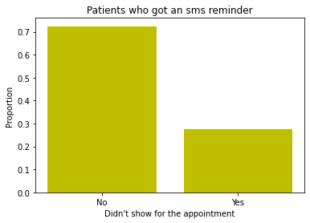

```python
# plot chart to show findings
locations = [1,2]
height = sms_received
labels=['No','Yes']

plt.bar(locations, height, color= 'y', tick_label=labels)

# add labels
plt.title('Patients who got an sms reminder')
plt.xlabel('Didn\'t show for the appointment')
plt.ylabel('Proportion');
```

```python
# didn't get an sms reminder and appointment attendance
sms_not_sent = proportions(sms_received_count[0],sms_received_total[0])
sms_not_sent
```

```
No_show
No     0.832967
Yes    0.167033
Name: Age, dtype: float64
```

[figure not shown]

```python
# plot chart to show findings
locations = [1,2]
height = sms_not_sent
labels=['No','Yes']

plt.bar(locations, height, color= 'y', tick_label=labels)

# add labels
plt.title('Patients who got an sms reminder')
plt.xlabel('Didn\'t show for the appointment')
plt.ylabel('Proportion');
```

**Predict appointment attendance by Hipertension**

I look at the effect of Hipertension on the patient's decision to attend appointments.

```python
# get the total of all people with hipertension
hipertension_total = df.groupby('Hipertension').Age.count()
hipertension_total
```

```
Hipertension
0    88726
1    21801
Name: Age, dtype: int64
```

```python
# get Hipertension distribution
hipertension_count = df.groupby(['Hipertension','No_show']).Age.count()
hipertension_count
```

```
Hipertension  No_show
0             No         70179
              Yes        18547
1             No         18029
              Yes         3772
Name: Age, dtype: int64
```

```python
# patients with hipertension
with_hipertension = proportions(hipertension_count[1],hipertension_total[1])
with_hipertension
```

```
No_show
No     0.82698
Yes    0.17302
Name: Age, dtype: float64
```

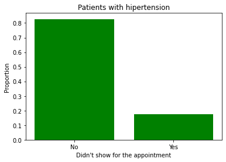

```python
# plot chart to show findings
locations = [1,2]
height = with_hipertension
labels=['No','Yes']

plt.bar(locations, height, color= 'g', tick_label=labels)

# add labels
plt.title('Patients with hipertension')
plt.xlabel('Didn\'t show for the appointment')
plt.ylabel('Proportion');
```

```python
# patients with hipertension
without_hipertension = proportions(hipertension_count[0],hipertension_total[0])
without_hipertension
```

```
No_show
No     0.790963
Yes    0.209037
Name: Age, dtype: float64
```

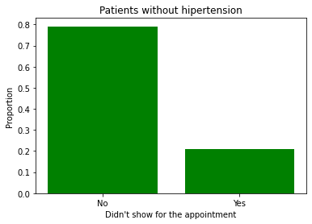

```python
# plot chart to show findings
locations = [1,2]
height = without_hipertension
labels=['No','Yes']

plt.bar(locations, height, color= 'g', tick_label=labels)

# add labels
plt.title('Patients without hipertension')
plt.xlabel('Didn\'t show for the appointment')
plt.ylabel('Proportion');
```

**Summary**

83% of patients with hipertension showed up for their appointment compared to 79% of patients without hipertension that showed up for their appointment. This variable can be used to predict whether patients show up for their appointments or not.

**Predict appointment attendance by Diabetes**

Look at the possibility of patients making it to their appointments depending on whether they got Diabetes or not.

```python
# get the total of all people with Diabetes
diabetes_total = df.groupby('Diabetes').Age.count()
diabetes_total
```

```
Diabetes
0    102584
1      7943
Name: Age, dtype: int64
```

```python
# get Diabetes distribution
diabetes_count = df.groupby(['Diabetes','No_show']).Age.count()
diabetes_count
```

```
Diabetes  No_show
0         No         81695
          Yes        20889
1         No          6513
          Yes         1430
Name: Age, dtype: int64
```

```python
#proportions for patients with diabetes
with_diabetes = proportions(diabetes_count[1],diabetes_total[1])
with_diabetes
```

```
No_show
No     0.819967
Yes    0.180033
Name: Age, dtype: float64
```

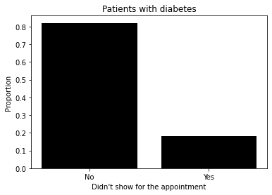

```python
# plot chart to show findings
locations = [1,2]
height = with_diabetes
labels=['No','Yes']

plt.bar(locations, height, color= 'k', tick_label=labels)

# add labels
plt.title('Patients with diabetes')
plt.xlabel('Didn\'t show for the appointment')
plt.ylabel('Proportion');
```

```python
# get proportion without diabetes that showed or not
without_diabetes = proportions(diabetes_count[0],diabetes_total[0])
without_diabetes
```

```
No_show
No     0.796372
Yes    0.203628
Name: Age, dtype: float64
```

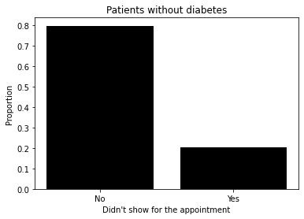

```python
# plot chart to show findings
locations = [1,2]
height = without_diabetes
labels=['No','Yes']

plt.bar(locations, height, color= 'k', tick_label=labels)

# add labels
plt.title('Patients without diabetes')
plt.xlabel('Didn\'t show for the appointment')
plt.ylabel('Proportion');
```

**Summary**

82% of patients that have diabetes showed up compared to 80% of patients that don't have diabetes that showed up. This might indicate that this variable can be used to predict whether patients attend appointments.

```python
np.unique(df['Handcap'])
```

```
array([0, 1, 2, 3, 4], dtype=int64)
```

I couldn't find the explanation of the different values for handcap therefore wasn't able to do a deep dive into the handcap variable.

## Conclusions

> **Conclusion** From the dataset provided and the variables selected, the variables don't strongly indicate a relationship between the chosen variables and a patient showing up or not.

> **Limitation** Simple statistical analysis was carried out to understand the correlation between the chosen variables, no machine learning model were used. This may have limited the results that we could draw from this dataset, compared to when a more statistical approach had been chosen.

> **Resources used** https://pandas.pydata.org/pandas-docs/stable/index.html | https://matplotlib.org/stable/index.html